# HW 2: From correlation to linear mixed-effect models. Assignment sheet

### 2.4 Use the mixed-efects model to predict `Mean_RT` by `log(SUBTLWF)` using POS intercept as a random effect

```r
model2_2 <- lmer(Mean_RT~log(SUBTLWF) + (1 | POS), data=elp)
fixef(model2_2)
```

```
##  (Intercept) log(SUBTLWF)
##    767.70941    -37.66598
```

#### 2.4.1 Provide the fixed effects formula

$$767.70941-37.666 \cdot x$$

#### 2.4.2 Provide the variance for intercept argument for `POS` random effects

$$414.4$$

#### 2.4.3 Add the regression line to the scatterplot

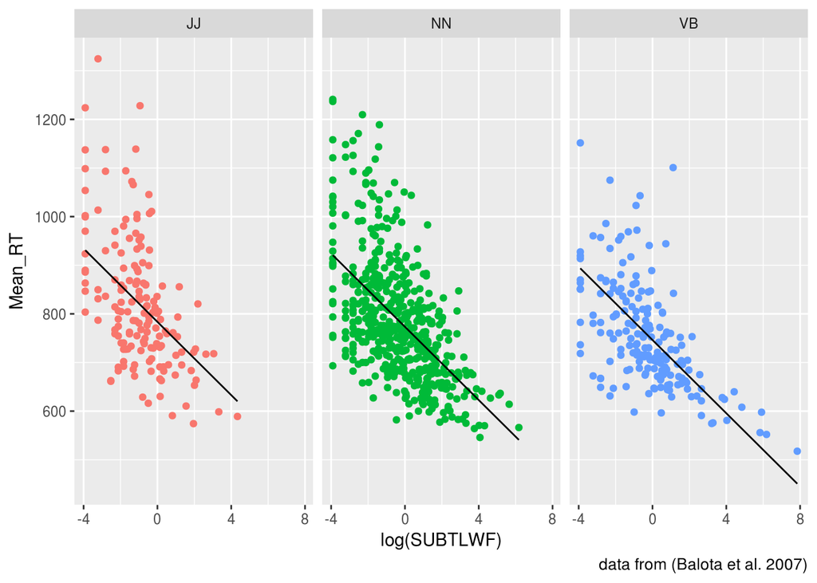

```r
model2_2_new <- lmer(Mean_RT~log(SUBTLWF) + (1 | POS), data=elp)
elp$model2_2_new_prediction <- predict(model2_2_new)

elp %>%
  ggplot(aes(log(SUBTLWF), Mean_RT, color=POS)) +
  geom_point() +
  facet_wrap(~POS) +
  geom_line(aes(log(SUBTLWF), model2_2_new_prediction), color='black') +
  labs(caption='data from (Balota et al. 2007)') +
  theme(legend.position='none')
```

## 3. Dutch causative constructions

This is a data set with examples of two Dutch periphrastic causatives extracted from newspaper corpora.

The data frame includes 100 observations on the following 7 variables:

- Cx – a factor with levels doen_V and laten_V
- CrSem – a factor that contains the semantic class of the Causer with levels Anim (animate) and Inanim (inanimate).
- CeSem – a factor that describes the semantic class of the Causee with levels Anim (animate) and Inanim (inanimate).
- CdEv – a factor that describes the semantic domain of the caused event expressed by the Effected Predicate. The levels are Ment (mental), Phys (physical) and Soc (social).
- Neg – a factor with levels No (absence of negation) and Yes (presence of negation).
- Coref – a factor with levels No (no coreferentiality) and Yes (coreferentiality).
- Poss – a factor with levels No (no overt expression of possession) Yes (overt expression of possession)

Data from Natalya Levshina’s `RLing` package available (here)[https://raw.githubusercontent.com/agricolamz/2018-MAG_R_course/master/data/dutch_causatives.csv]

### 3.0 Read the data from file to the variable `d_caus`.

### 3.1 We are going to test whether the association between `Aux` and other categorical variables (`Aux` ~ `CrSem`, `Aux` ~ `CeSem`, etc) is statistically significant. The assiciation with which variable should be analysed using Fisher’s Exact Test and not using Pearson’s Chi-squared Test? Is this association statistically significant?

### 3.2. Test the hypothesis that `Aux` and `EPTrans` are not independent with the help of Pearson’s Chi-squared Test.

### 3.3 Provide expected values for Pearson’s Chi-squared Test of `Aux` and `EPTrans` variables.

### 3.4. Calculate the odds ratio.

### 3.5 Calculate effect size for this test using Cramer’s V (phi).

### 3.6. Report the results of independence test using the following template:

```
We have / have not found a significant association between variables ... and ... (p < 0.001).  The odds of ... were ... times higher / lower in (group ....) than in (group ....). Effect size is large / medium / small (Cramer's V = ....).
```

### 3.7 Visualize the distribution using mosaic plot.

Use `mosaic()` function from `vcd` library.

Below is an example of how to use mosaic() with three variables.

```r
# mosaic(~ Aux + CrSem + Country, data=d_caus, shade=TRUE, legend=TRUE)
```

### 3.8 Why is it not recommended to run multiple Chisq tests of independence on different variables within your dataset whithout adjusting for the multiplicity? (i.e. just testing all the pairs of variables one by one)

### 3.9 Provide a short text (300 words) describing the hypothesis on this study and the results of your analysis.